# ASSIGNMENT 4 - DATA SETS

Molly Siebecker & Marley Myrianthopoulos

CUNY SPS

DATA 620

Summer 2024

## PROVIDED CODE

The following code can be found [here](https://networkx.org/documentation/stable/auto_examples/algorithms/plot_davis_club.html), it was provided as part of the assignment directions.

```
Biadjacency matrix
<Compressed Sparse Row sparse array of dtype 'int64'
	with 89 stored elements and shape (18, 14)>
  Coords	Values
  (0, 0)	1
  (0, 1)	1
  (0, 2)	1
  (0, 3)	1
  (0, 4)	1
  (0, 5)	1
  (0, 7)	1
  (0, 8)	1
  (1, 0)	1
  (1, 1)	1
  (1, 2)	1
  (1, 4)	1
  (1, 5)	1
  (1, 6)	1
  (1, 7)	1
  (2, 1)	1
  (2, 2)	1
  (2, 3)	1
  (2, 4)	1
  (2, 5)	1
  (2, 6)	1
  (2, 7)	1
  (2, 8)	1
  (3, 0)	1
  (3, 2)	1
  :	:
  (12, 7)	1
  (12, 8)	1
  (12, 9)	1
  (12, 11)	1
  (12, 12)	1
  (12, 13)	1
  (13, 5)	1
  (13, 6)	1
  (13, 8)	1
  (13, 9)	1
```

[output cut: 40 more lines]

```
46 Brenda Rogers
24 Charlotte McDowd
32 Frances Anderson
36 Eleanor Nye
31 Pearl Oglethorpe
40 Ruth DeSand
38 Verne Sanderson
33 Myra Liddel
37 Katherina Rogers
46 Sylvia Avondale
43 Nora Fayette
34 Helen Lloyd
24 Dorothy Murchison
14 Olivia Carleton
14 Flora Price
```

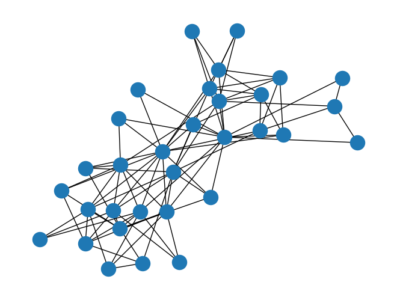

```python
import matplotlib.pyplot as plt
import networkx as nx
from networkx.algorithms import bipartite

G = nx.davis_southern_women_graph()
women = G.graph["top"]
clubs = G.graph["bottom"]

print("Biadjacency matrix")
print(bipartite.biadjacency_matrix(G, women, clubs))

# project bipartite graph onto women nodes
W = bipartite.projected_graph(G, women)
print()
print("#Friends, Member")
for w in women:
    print(f"{W.degree(w)} {w}")

# project bipartite graph onto women nodes keeping number of co-occurrence
# the degree computed is weighted and counts the total number of shared contacts
W = bipartite.weighted_projected_graph(G, women)
print()
print("#Friend meetings, Member")
for w in women:
    print(f"{W.degree(w, weight='weight')} {w}")

pos = nx.spring_layout(G, seed=648)  # Seed layout for reproducible node positions
nx.draw(G, pos)
plt.show()
```

**TASK**:

What can you infer about the relationships between (1) the women, and (2) the social events?

## ANALYSIS OF SOCIAL EVENTS

### EVENTS PROJECTION

To investigate the relationships between the social events, we begin with a projection graph, where each node is an event and each edge connecting two nodes means that the two events represented by those nodes had a guest in common.

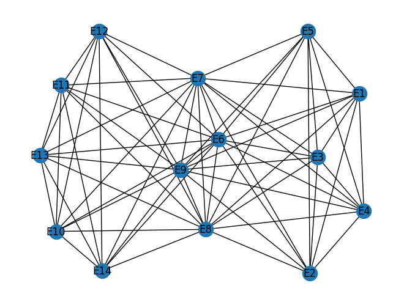

```
Density =  0.7252747252747253
Diameter =  2
```

```python
E = bipartite.projected_graph(G, clubs)
pos3 = nx.spring_layout(E, seed=1989)
nx.draw(E, pos3, with_labels=True)
plt.show()
print("Density = ", nx.density(E), "\nDiameter = ", nx.diameter(E))
```

We can see from the summary statistics that the events are pretty well connected (the density of the graph is close to 1), but there are some events that do not have any common attendees (since the density is less than 1 and the diameter is greater than 1). By graphing just the events in the periphery set, we can investigate the events with no common attendees.

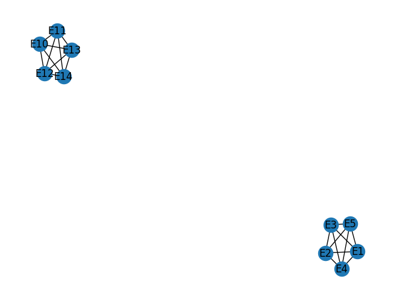

```python
E_periphery = E.subgraph(nx.periphery(E))
pos4 = nx.spring_layout(E_periphery, seed=1989)
nx.draw(E_periphery, pos4, with_labels=True)
plt.show()
```

This graph reveals that the events E1-E5 are a do not have any common attendees with the events E10-E14. We can investigate these two subgroups by creating subgraphs for them.

### EVENTS SUBGROUP 1

We start by creating a subgraph of the Events projection that contains only the nodes for events E1-E5 and calculating the summary statistics for this graph.

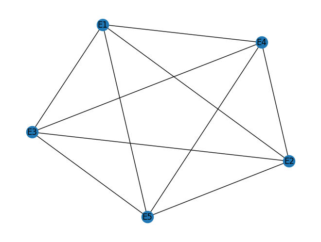

```
Density =  1.0
Diameter =  1
```

```python
E_sub_1_list = ["E1", "E2", "E3", "E4", "E5"]
E_sub_1 = E.subgraph(E_sub_1_list)
pos5 = nx.spring_layout(E_sub_1, seed=1989)
nx.draw(E_sub_1, pos5, with_labels=True)
plt.show()
print("Density = ", nx.density(E_sub_1), "\nDiameter = ", nx.diameter(E_sub_1))
```

The subgraph of events E1-E5 has a density and diameter of 1, meaning it is a "complete graph," every possible pair of nodes are connected by an edge. This means that every event in the subgroup has a common attendee with every other event in the subgroup.

By determining the degree of the nodes representing events E1-E5 in the original graph, we can determine how many attendees each event had.

```python
print(list([event, G.degree(event)] for event in E_sub_1_list))
```

```
[['E1', 3], ['E2', 3], ['E3', 6], ['E4', 4], ['E5', 8]]
```

E5 was the best attended event in this subgroup, with 8 guests. E1 and E2 were the worst attended, with only 3.

### EVENTS SUBGROUP 2

We now perform the same analysis with the subgraph of the Events projection that contains only the nodes for events E10-E14 and calculating the summary statistics for this graph.

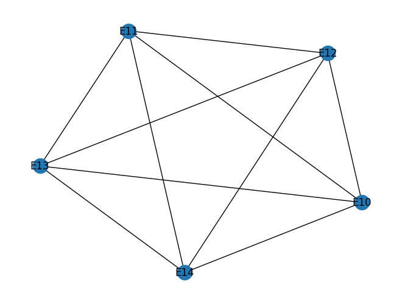

```
Density =  1.0
Diameter =  1
```

```python
E_sub_2_list = ["E10", "E11", "E12", "E13", "E14"]
E_sub_2 = E.subgraph(E_sub_2_list)
pos6 = nx.spring_layout(E_sub_2, seed=1989)
nx.draw(E_sub_2, pos6, with_labels=True)
plt.show()
print("Density = ", nx.density(E_sub_2), "\nDiameter = ", nx.diameter(E_sub_2))
```

Like the previous subgraph, the subgraph of events E10-E14 has a density and diameter of 1, making another "complete graph." Every event in the subgroup has a common attendee with every other event in the subgroup.

By determining the degree of the nodes representing events E10-E14 in the original graph, we can determine how many attendees each event had.

```python
print(list([event, G.degree(event)] for event in E_sub_2_list))
```

```
[['E10', 5], ['E11', 4], ['E12', 6], ['E13', 3], ['E14', 3]]
```

E12 was the best attended event in this subgroup, with 6 guests. E13 and E14 were the worst attended, with only 3.

### EVENTS BRIDGE NODES

We can investigate the relationship between the "bridge" events E6-E9 that connect the two subgroups by graphing the subgraph of the events projection that contains only these nodes and calculating the summary statistics.

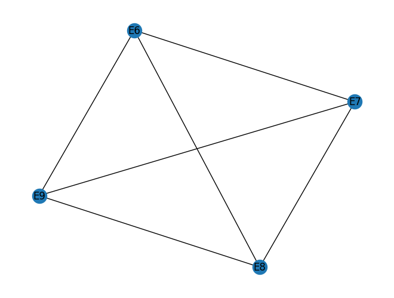

```
Density =  1.0
Diameter =  1
```

```python
bridge_events = ["E6", "E7", "E8", "E9"]
E_bridge = E.subgraph(bridge_events)
pos7 = nx.spring_layout(E_bridge, seed=1989)
nx.draw(E_bridge, pos7, with_labels=True)
plt.show()
print("Density = ", nx.density(E_bridge), "\nDiameter = ", nx.diameter(E_bridge))
```

Like the subgroups, the subgraph of the bridge events is a complete graph, meaning every pair of bridge events have at least one common guest. Also like the subgroups, we can find the number of attendees for each event by finding the degree of the node representing that event in the original graph.

```python
print(list([event, G.degree(event)] for event in bridge_events))
```

```
[['E6', 8], ['E7', 10], ['E8', 14], ['E9', 12]]
```

E8 was the best attended event in this subgroup, with 14 attendees. E6 was the worst attended, with only 8 attendees.

### CONNECTING THE SUBGROUPS

Now, we look at how well each of the bridge events is connected to the two subgroups by considering each bridge event and creating a subgraph with the two subgroups and that one bridge event. After creating the subgraph, we can find the degree of the node representing the bridge event to determine how well connected it is to the events from the subgroups (the maximum degree would be 10, indicating that the bridge event has guests in common with every event from both subgroups).

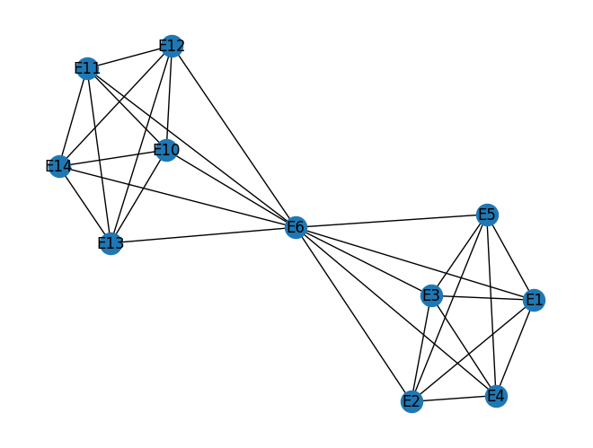

```
E6 Degree: 10
```

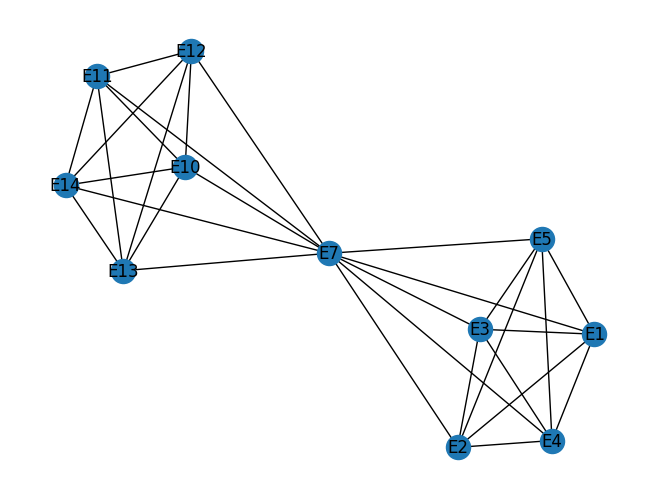

```
E7 Degree: 10
```

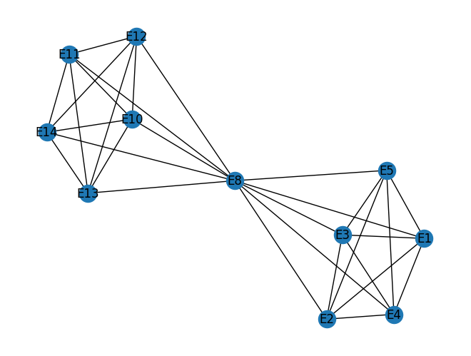

```
E8 Degree: 10
```

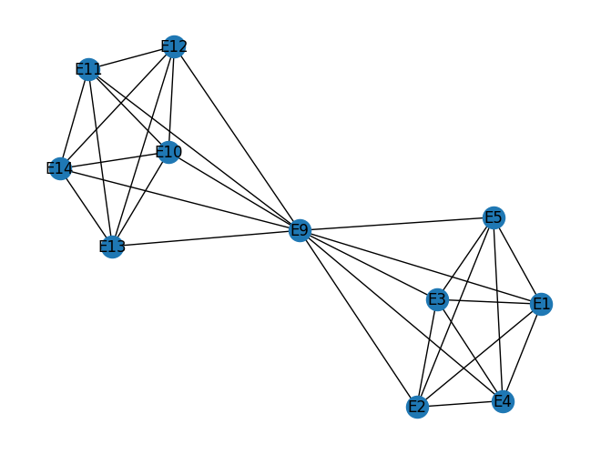

```
E9 Degree: 10
```

```python
for event in bridge_events:
    E_bridge_loop = E.subgraph(E_sub_1_list + E_sub_2_list + [event])
    pos_bridge = nx.spring_layout(E_bridge_loop, seed=1989)
    nx.draw(E_bridge_loop, pos_bridge, with_labels=True)
    plt.show()
    print(event, "Degree:", E_bridge_loop.degree(event))
```

Each of the bridge events has at least one guest in common with all five of the events from subgroup one *and* all five of the events from subgroup two.

### EVENTS CONCLUSIONS

From our analysis of the events, we are able to conclude the following:

1. The events are attended by two distinct social circles, one of which attends events E1-E5 but not events E10-E14, and one of which attends events E10-E14 but not events E1-E5.
2. Each of the events in the subgroup E1-E5 have attendees in common with each of the other events in the subgroup. The same is true for each of the events in the subgroup E10-E14.
3. Events E6-E9 are events where the two social circles mix. Each of these events has attendees in common with each of the other events in this subgroup, and each of these events has attendees in common with each of the events from subgroup E1-E5 *and* subgroup E10-E14.

## ANALYSIS OF WOMEN

### WOMEN PROJECTION

To investigate the relationships between the women, we begin with a projection graph, where each node is one of the women and each edge connecting two nodes means that the two women represented by those nodes attended at least one event together.

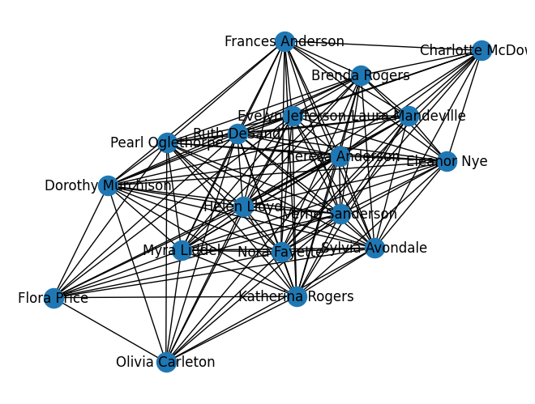

```
Density =  0.9084967320261438
Diameter =  2
```

```python
pos8 = nx.spring_layout(W, seed=1989)
nx.draw(W, pos8, with_labels=True)
plt.show()
print("Density = ", nx.density(W), "\nDiameter = ", nx.diameter(W))
```

As with the events projection, we can see from the summary statistics that the women are pretty well connected (the density of the graph is close to 1), but there are some women that did not attend any events together (since the density is less than 1 and the diameter is greater than 1). By graphing just the women in the periphery set, we can investigate the women who are strangers.

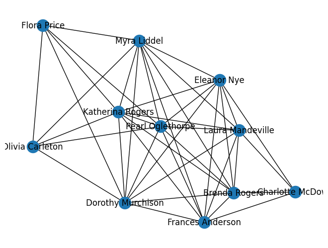

```python
W_periphery = W.subgraph(nx.periphery(W))
pos9 = nx.spring_layout(W_periphery, seed=1989)
nx.draw(W_periphery, pos9, with_labels=True)
plt.show()
```

Unlike with the events, the periphery graph does not clearly indicate the existence of subgroups within the set of women. However, we know from our analysis of the events that there are two distinct social circles or "cliques," one of which attends events E1-E5 but not events E10-E14, and one of which attends events E10-E14 but not events E1-E5. We further know that these groups "mix" in events E6-E9. We can investigate these two cliques by creating subgraphs for them.

### WOMEN CLIQUE 1

We start by creating a subgraph of the women projection that contains only the nodes for the women who attended events E1-E5 and calculating the summary statistics for this graph.

```
Clique 1: ['Evelyn Jefferson', 'Eleanor Nye', 'Laura Mandeville', 'Theresa Anderson', 'Frances Anderson', 'Ruth DeSand', 'Brenda Rogers', 'Charlotte McDowd']
```

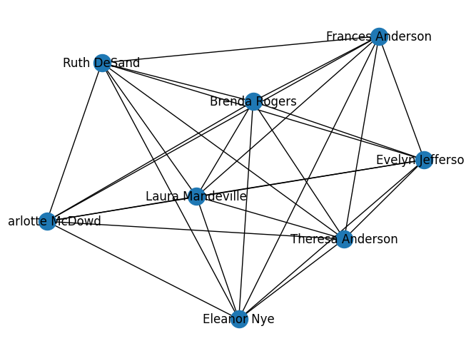

```
Density =  1.0
Diameter =  1
```

```python
clique_1 = list(set([(women) for women, events in G.edges if events in E_sub_1_list]))
print("Clique 1:", clique_1)
W_sub_1 = W.subgraph(clique_1)
pos10 = nx.spring_layout(W_sub_1, seed=1989)
nx.draw(W_sub_1, pos10, with_labels=True)
plt.show()
print("Density = ", nx.density(W_sub_1), "\nDiameter = ", nx.diameter(W_sub_1))
```

The subgraph of clique 1 (the women who attended events E1-E5) has a density and diameter of 1, meaning it is a "complete graph," every possible pair of nodes are connected by an edge. This means that every woman in the clique has attended at least one event with every other woman in the clique.

By creating a graph with the women in clique 1 and the events E1-E5, we can determine which women were the most active in attending "their" events.

```python
clique_1_events = G.subgraph(E_sub_1_list + clique_1)
for woman in clique_1:
    print(woman, clique_1_events.degree(woman))
```

```
Evelyn Jefferson 5
Eleanor Nye 1
Laura Mandeville 4
Theresa Anderson 4
Frances Anderson 2
Ruth DeSand 1
Brenda Rogers 4
Charlotte McDowd 3
```

By creating a list of women who did not attend any events except E1-E5, we can determine which of the women in this clique are "shy" (here meaning that they do not attend the "bridge" events where the cliques mix).

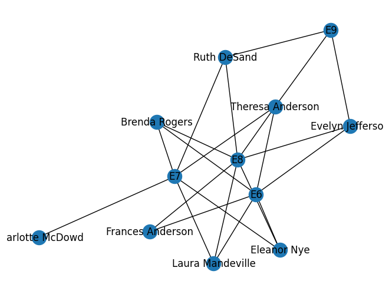

```python
shy_clique_1 = G.subgraph(bridge_events + clique_1)
pos11 = nx.spring_layout(shy_clique_1, seed=1989)
nx.draw(shy_clique_1, pos11, with_labels=True)
plt.show()
```

Since there are no nodes disconnected in this graph, every woman in clique 1 attended at least one bridge event, and every bridge event was attended by at least one woman in clique 1. By finding the degree of each of the women in clique 1 in this graph, we can determine how many of the bridge events each of them attended.

```python
for woman in clique_1:
    print(woman, shy_clique_1.degree(woman))
```

```
Evelyn Jefferson 3
Eleanor Nye 3
Laura Mandeville 3
Theresa Anderson 4
Frances Anderson 2
Ruth DeSand 3
Brenda Rogers 3
Charlotte McDowd 1
```

Theresa Anderson was the least "shy" of the women in clique 1, attending all four bridge events. Charlotte McDowd was the most "shy," attending only one of them.

### WOMEN CLIQUE 2

We now replicate this analysis for the women in clique 2 (those who attended events E10-E14).

```
Clique 2: ['Olivia Carleton', 'Nora Fayette', 'Katherina Rogers', 'Helen Lloyd', 'Verne Sanderson', 'Myra Liddel', 'Sylvia Avondale', 'Flora Price']
```

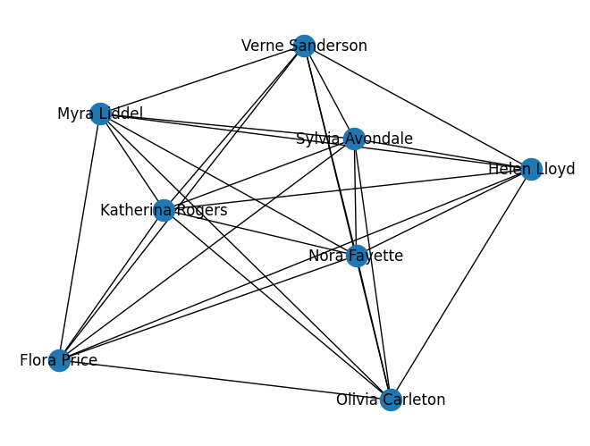

```
Density =  1.0
Diameter =  1
```

```python
clique_2 = list(set([(women) for women, events in G.edges if events in E_sub_2_list]))
print("Clique 2:", clique_2)
W_sub_2 = W.subgraph(clique_2)
pos12 = nx.spring_layout(W_sub_2, seed=1989)
nx.draw(W_sub_2, pos12, with_labels=True)
plt.show()
print("Density = ", nx.density(W_sub_2), "\nDiameter = ", nx.diameter(W_sub_2))
```

As with clique 1, the subgraph of clique 2 (the women who attended events E10-E14) has a density and diameter of 1, meaning it is a "complete graph," every possible pair of nodes are connected by an edge. This means that every woman in the clique has attended at least one event with every other woman in the clique.

By creating a graph with the women in clique 2 and the events E10-E14, we can determine which women were the most active in attending "their" events.

```python
clique_2_events = G.subgraph(E_sub_2_list + clique_2)
for woman in clique_2:
    print(woman, clique_2_events.degree(woman))
```

```
Olivia Carleton 1
Nora Fayette 5
Katherina Rogers 4
Helen Lloyd 3
Verne Sanderson 1
Myra Liddel 2
Sylvia Avondale 4
Flora Price 1
```

Nora Fayette was the most active member of clique 2 in terms of attending their events, she was at all 5. Olivia Carleton, Flora Price, and Verne Sanderson were the least active, attending only 1.

By creating a list of women who did not attend any events except E10-E14, we can determine which of the women in this clique are "shy" (here meaning that they do not attend the "bridge" events where the cliques mix).

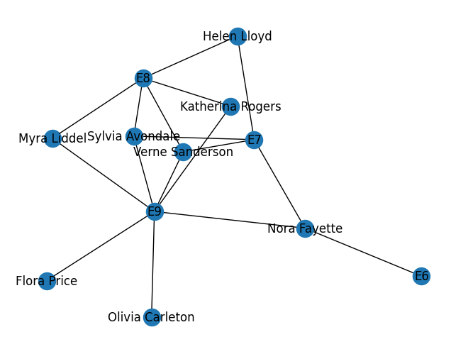

```python
shy_clique_2 = G.subgraph(bridge_events + clique_2)
pos13 = nx.spring_layout(shy_clique_2, seed=1989)
nx.draw(shy_clique_2, pos13, with_labels=True)
plt.show()
```

Since there are no nodes disconnected in this graph, every woman in clique 2 attended at least one bridge event, and every bridge event was attended by at least one woman in clique 2. By finding the degree of each of the women in clique 2 in this graph, we can determine how many of the bridge events each of them attended.

```python
for woman in clique_2:
    print(woman, shy_clique_2.degree(woman))
```

```
Olivia Carleton 1
Nora Fayette 3
Katherina Rogers 2
Helen Lloyd 2
Verne Sanderson 3
Myra Liddel 2
Sylvia Avondale 3
Flora Price 1
```

Sylvia Avondale, Nora Fayette, and Verne Sanderson were the least "shy" of the women in clique 2, attending three of the four bridge events. Olivia Carleton and Flora Price were the most "shy," attending only one of them.

### WOMEN IN NEITHER CLIQUE

We can also check if there are women who did not attend events E1-E5 OR E10-E14 and are therefore in neither clique, but who did attend the bridge events.

```python
outsiders = [
    (woman, event)
    for woman, event in G.edges
    if woman not in clique_1 and woman not in clique_2
]
outsiders
```

```
[('Pearl Oglethorpe', 'E6'),
 ('Pearl Oglethorpe', 'E8'),
 ('Pearl Oglethorpe', 'E9'),
 ('Dorothy Murchison', 'E8'),
 ('Dorothy Murchison', 'E9')]
```

Pearl Oglethorpe attended three of the bridge events (E6, E8, and E9) and Dorothy Murchison attended two (E8 and E9).

### WOMEN CONCLUSIONS

From our analysis of the women, we are able to conclude the following:

1. The women are divided into two cliques, one of which attended events E1-E5 but not events E10-E14 (clique 1), and one of which attended events E10-E14 but not events E1-E5 (clique 2).
2. Clique 1 is made up of Eleanor Nye, Ruth DeSand, Brenda Rogers, Laura Mandeville, Evelyn Jefferson, Frances Anderson, Charlotte McDowd, and Theresa Anderson. Each combination of two of these women have attended at least one event together.
3. Clique 2 is made up of Myra Liddel, Sylvia Avondale, Olivia Carleton, Flora Price, Nora Fayette, Katherina Rogers, Helen Lloyd, and Verne Sanderson. Each combination of two of these women have attended at least one event together.
4. Each bridge event was attended by at least one woman from at each clique.
5. Pearl Oglethorpe and Dorothy Murchison are not in either clique (they only attended bridge events). Pearl attended three of the four bridge events, and Dorothy attended two.